# Solución_HOTBED

## Solución

### Análisis Circuital

A la hora de resolver el problema, se va a dividir 6 resistencias diferentes, que podemos apreciar en el documento de altium proporcionado.

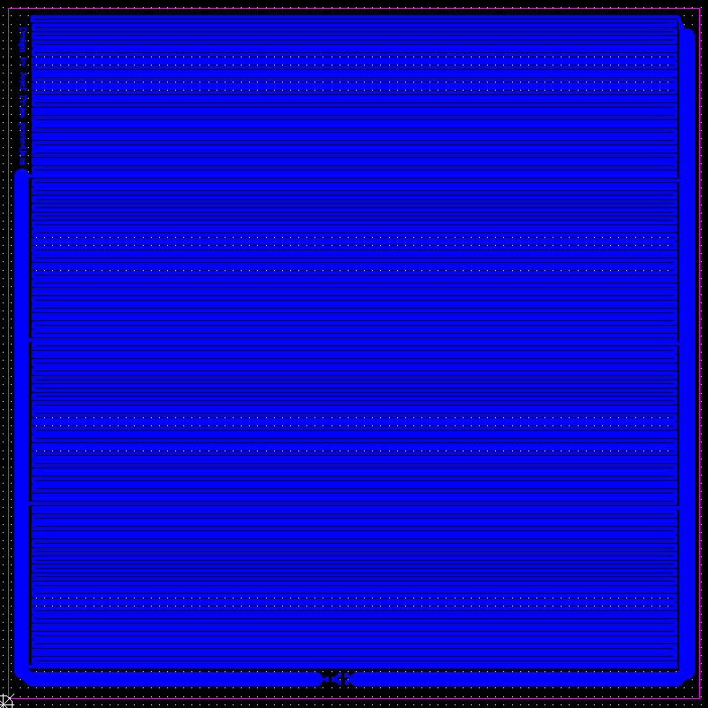

Fig. 1: PCB de la cama caliente

Pulsando el shift y colocando el ratón encima del modelo 2D de la cama caliente, podremos ver como sobresaltan 6 partes, que son las siguientes: |

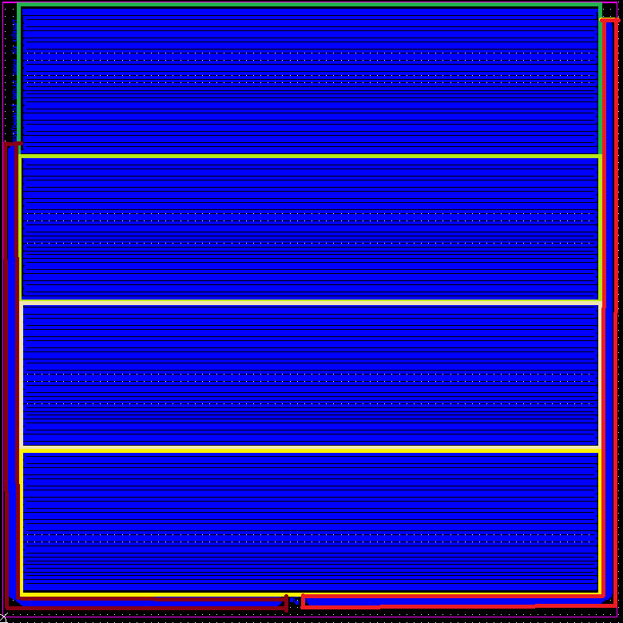

[output not shown]

Viendo esta nueva, imagen, se puede modelar la cama como una asociación de resistencias de la siguiente manera: |

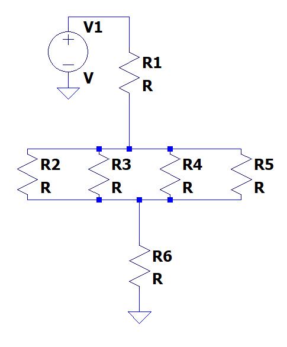

[output not shown]

### Cálculo de las resistencias equivalentes

Tras haber obtenido el modelo al que corresponde la cama, se pasa a obtener el valor de cada una de ellas. Para ello tendremos en cuenta:

```
I. Resistivdad del cobre.

II. Grosor de la capa de cobre.

III. Dimensiones de cada una de las resistencias.
```

**Resistencia en función de la resistividad, grosor, longitud y ancho:**

$R = \frac{\rho}{A} \cdot \frac{L}{W}$ ]

donde:

- ( R ) es la resistencia,
- ( \rho ) es la resistividad del material,
- ( A ) es el área transversal,
- ( L ) es la longitud de la pista, y
- ( W ) es el ancho de la pista.

#### Cálculo de R1 (Marrón)

En primer lugar se va a obtener la resistencia R1, que corresponde a la subrayada en color marrón en la figura anterior. Tras analizarla con detenimiento, se puede ver que está conformada por tres tramos con dimensiones diferentes: (W X L)

```
I. Primer tramo: 177.165mil x 6043.302mil

II. Segundo tramo: 177.165mil x 3444.883mil

III. Tercer tramo: 129.921mil x 169.337mil
```

```python
import sys
import math
##VARIABLES GLOBALES ÚTILES:
resistividad_Cu = 1.7675*(1e-8)
grosor_17um = 17.5*(1e-6)
grosor_35um = 35*(1e-6)
```

```python
mils2m = 1/(39.37*1e-3)

#TRAMO 1, factor L/W: 177.165mil X 6043.302mil
R1_LWT1_1MILS = 6043.302/177.165
#TRAMO 2, factor L/W:  177.165mil x 3444.883mil
R1_LWT1_2MILS = 3444.883/177.165
#TRAMO 3, factor L/W: 129.921mil x 169.337mil
R1_LWT1_3MILS = 169.337/129.921

R1_LWT1_1M = R1_LWT1_1MILS * mils2m
R1_LWT1_2M = R1_LWT1_2MILS * mils2m
R1_LWT1_3M = R1_LWT1_3MILS * mils2m

R1_TRAMO1_17u = (resistividad_Cu/grosor_17um)*(R1_LWT1_1M + R1_LWT1_2M + R1_LWT1_3M)
R1_TRAMO1_35u = (resistividad_Cu/grosor_35um)*(R1_LWT1_1M + R1_LWT1_2M + R1_LWT1_3M)


print ('Resistencia R1 para 17.5 um =',R1_TRAMO1_17u,' Ω')
print ('Resistencia R1 para 35 um =',R1_TRAMO1_35u,' Ω')
```

```
Resistencia R1 para 17.5 um = 1.4073562314605896  Ω
Resistencia R1 para 35 um = 0.7036781157302948  Ω
```

#### Cálculo de R2, R3, R4, R5

A la hora de obtener la resistencia equivalente formada por estas, se tendrán en cuenta que las medidas pueden variar entre una pista y otra:

Observando con detenimiento este segmento, se puede ver que tiene cuenta con 3 geometrías más que se tendrán que tener en cuenta a la hora del cálculo.

Por lo tanto esta contará(W x L):

[output not shown]

Además, las 4 son idénticas, por lo que sólo hará falta calcular la primera.

```python
# Cálculo de L/W para cada tipo de tramo en mils
# Tramo I: 1 tramo largo
R2_LWT1_1MILS = 7881.887 / 43.307

# Tramo II: 38 tramos
R2_LWT1_2MILS = 7830.706 / 43.307

# Tramo III: 38 tramos
R2_LWT1_3MILS = 51.18 / 43.307

# Conversión de cada L/W de mils a metros
R2_LWT1_1M = R2_LWT1_1MILS * mils2m
R2_LWT1_2M = R2_LWT1_2MILS * mils2m
R2_LWT1_3M = R2_LWT1_3MILS * mils2m

# Cálculo de la resistencia total para 17.5 um y 35 um de espesor
R2_TOTAL_17u = (resistividad_Cu / grosor_17um) * (2*R2_LWT1_1M + 37 * R2_LWT1_2M + 38 * R2_LWT1_3M)
R2_TOTAL_35u = (resistividad_Cu / grosor_35um) * (2*R2_LWT1_1M + 37 * R2_LWT1_2M + 38 * R2_LWT1_3M)

print("Resistencia R2 para 17.5 um =", R2_TOTAL_17u, "Ω")
print("Resistencia R2 para 35 um =", R2_TOTAL_35u, "Ω")
```

```
Resistencia R2 para 17.5 um = 182.12305243378816 Ω
Resistencia R2 para 35 um = 91.06152621689408 Ω
```

Por lo tanto, el valor de estas cuatro resistencias en paralelo será: La resistencia total en paralelo se calcula como:

$$ \frac{1}{R_{\text{total}}} = \frac{1}{R_2} + \frac{1}{R_3} + \frac{1}{R_4} + \frac{1}{R_5} $$

```python
# Cálculo de la resistencia equivalente en paralelo
R_paralelo_17u = (1/R2_TOTAL_17u + 1/R2_TOTAL_17u + 1/R2_TOTAL_17u + 1/R2_TOTAL_17u) ** -1
R_paralelo_35u = (1/R2_TOTAL_35u + 1/R2_TOTAL_35u + 1/R2_TOTAL_35u + 1/R2_TOTAL_35u) ** -1

print("Resistencia R equivalente para 17.5 um =", R_paralelo_17u, "Ω")
print("Resistencia R equivalente para 35 um =", R_paralelo_35u, "Ω")
```

```
Resistencia R equivalente para 17.5 um = 45.53076310844704 Ω
Resistencia R equivalente para 35 um = 22.76538155422352 Ω
```

#### Cálculo de R6 (Rojo)

[figure not shown]

Fig. 4: Partes de R6

```
I. Primer tramo: 177.165mil x 6043.302mil

II. Segundo tramo: 177.165mil x 3444.883mil

III. Tercer tramo: 129.921mil x 169.337mil

IV. Cuarto tramo: 43.307mil x 16.709mil

V. Quinto tamo: 43.307mil x 94.648mil

VI. Sexto tramo: 66mil x 144.385mil
```

```python
# Cálculo de L/W para cada tipo de tramo en mils
# I. Primer tramo
R6_LWT1_1MILS = 6043.302/ 177.165

# II. Segundo tramo
R6_LWT1_2MILS = 3444.883/177.165

# III. Tercer tramo
R6_LWT1_3MILS = 169.337/ 129.921

# IV. Cuarto tramo
R6_LWT1_4MILS = 16.709/43.307

# V. Quinto tramo
R6_LWT1_5MILS = 94.648/43.307

# VI. Sexto tramo
R6_LWT1_6MILS = 144.385/66

# Conversión de cada L/W de mils a metros
R6_LWT1_1M = R6_LWT1_1MILS * mils2m
R6_LWT1_2M = R6_LWT1_2MILS * mils2m
R6_LWT1_3M = R6_LWT1_3MILS * mils2m
R6_LWT1_4M = R6_LWT1_4MILS * mils2m
R6_LWT1_5M = R6_LWT1_5MILS * mils2m
R6_LWT1_6M = R6_LWT1_6MILS * mils2m

# Cálculo de la resistencia total para 17.5 um y 35 um de espesor
R6_TOTAL_17u = (resistividad_Cu / grosor_17um) * (R6_LWT1_1M+R6_LWT1_2M+R6_LWT1_3M+R6_LWT1_4M+R6_LWT1_5M+R6_LWT1_6M)
R6_TOTAL_35u = (resistividad_Cu / grosor_35um) * (R6_LWT1_1M+R6_LWT1_2M+R6_LWT1_3M+R6_LWT1_4M+R6_LWT1_5M+R6_LWT1_6M)

print("Resistencia R6 para 17.5 um =", R6_TOTAL_17u, "Ω")
print("Resistencia R6 para 35 um =", R6_TOTAL_35u, "Ω")
```

```
Resistencia R6 para 17.5 um = 1.529443631300101 Ω
Resistencia R6 para 35 um = 0.7647218156500505 Ω
```

Por lo tanto, la resistencia final que se obtiene es:

```python
#Calculo de la resistencia equivalente de la asociación final:
R_EQUIVALENTE_17um = R1_TRAMO1_17u + R_paralelo_17u + R6_TOTAL_17u
R_EQUIVALENTE_35um = R1_TRAMO1_35u + R_paralelo_35u + R6_TOTAL_35u

print("Resistencia final para 17.5 um =",R_EQUIVALENTE_17um, "Ω")
print("Resistencia final para 35 um =",R_EQUIVALENTE_35um, "Ω")
```

```
Resistencia final para 17.5 um = 48.467562971207734 Ω
Resistencia final para 35 um = 24.233781485603867 Ω
```

***Pregunta 1*** Se debe estimar la corriente que circula por ella cuando se alimenta a 12 V entre los terminales A y B, para ambos grosores de lámina de cobre.

```python
Vin = 12
#lEY DE OHM I = V/R
Intensidad_17um = Vin/R_EQUIVALENTE_17um
print ("Intensidad para 17.5 um =",Intensidad_17um,(" A"))
Intensidad_35um = Vin/R_EQUIVALENTE_35um
print ("Intensidad para 35 um =",Intensidad_35um,(" A"))
```

```
Intensidad para 17.5 um = 0.247588268614385  A
Intensidad para 35 um = 0.49517653722877  A
```

***Pregunta 2*** ¿Qué diferencia existe entre alimentar la cama caliente con 12V DC o con 12 V AC?

Al dar el voltaje en AC, vamos a calcular su valor efectivo: $$ V_{\text{efectivo}} = \frac{12}{\sqrt{2}} $$

```python
Vin_efectivo = Vin/(2**(1/2))
print ("Voltaje efectivo =",Vin_efectivo,(" V"))
```

```
Voltaje efectivo = 8.48528137423857  V
```

```python
#lEY DE OHM I = V/R
Intensidad_17um = Vin_efectivo/R_EQUIVALENTE_17um
print ("Intensidad para 17.5 um =",Intensidad_17um,(" A"))
Intensidad_35um = Vin_efectivo/R_EQUIVALENTE_35um
print ("Intensidad para 35 um =",Intensidad_35um,(" A"))
```

```
Intensidad para 17.5 um = 0.17507134367946806  A
Intensidad para 35 um = 0.3501426873589361  A
```

Como se puede ver, a diferencia que en la pregunta anterior, la intensidad ha disminuido, ya que al tratarse de AC, el valor efectivo será menor